# Estimating pi with GIS and Monte Carlo

```r
library(sp)
library(raster)
library(rgdal)
library(rgeos)
library(magrittr)
```

## Monte Carlo Methods

The fact that I was reading about Monte Carlo on Wikipedia is a pretty good indication of the amount I know about these techniques (not much!). So, I’ll resort to the concise definintion from [Wolfram](http://mathworld.wolfram.com/MonteCarloMethod.html):

> Any method which solves a problem by generating suitable random numbers and observing that fraction of the numbers obeying some property or properties.

This definition is a bit vague because the term encompasses a very broad class of algorithms spanning many disciplines. The key seems to be the use of repeated draws of random numbers from some probability distribution to solve a complex problem or simulate a complex system. I think the following two examples will make this more concrete.

## Incribed Circle Approach

[Wikipedia](https://en.wikipedia.org/wiki/Monte_Carlo_method#Introduction) gives the following method for estimating \( \pi \) as a simple example of a Monte Carlo method:

1. Draw a square with a circle inscribed within it. Note that the ratio of the areas of the circle and square is \( \pi / 4 \).
2. Randomly distribution a large number of points over the square, such that there is a uniform probability of a given point being anywhere within the square.
3. Count the number of points inside the circle and the total number of points.
4. The ratio of the numbers of points will equal the ratio of the areas (i.e. \( \pi / 4 \)), so multiplying this ratio by 4 will give an estimate of \( \pi \).

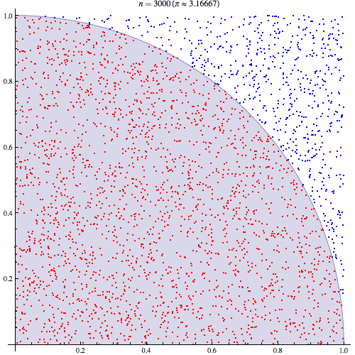

### R Implementation

First I draw a square with a circle inscribed.

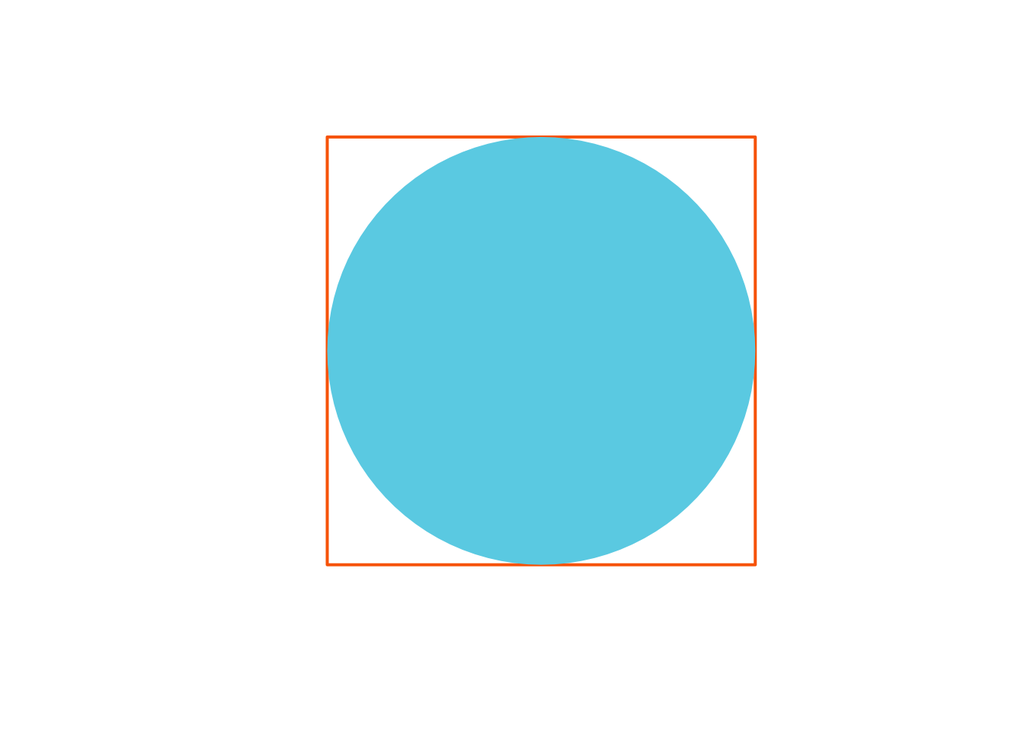

```r
square <- readWKT('POLYGON((-1 -1,-1 1,1 1,1 -1, -1 -1))')
circle <- readWKT('POINT(0 0)') %>%
  gBuffer(width = 1, quadsegs = 25)
plot(square, axes = F, border = '#FA6900', lwd = 2)
plot(circle, add = T, col = '#69D2E7', border = 'transparent')
```

[Well-known Text](https://en.wikipedia.org/wiki/Well-known_text) is a simple markup language for representing vector geometries in plain text, and `rgeos::readWKT()` creates spatial objects based on a WKT strings. It’s the easiest way I know of to quickly create simple geometries in R. To create the circle I create a buffer around I point. The `quadsegs` parameter in `rgeos::gBuffer()` sets the number of line segments to use to approximate a quarter circle, which is a measure of the smoothness of the buffering polygon. The default value of `quadsegs = 5` results in a circle with noticable edges, but `quadsegs = 25` seems to create a nice smooth circle.

Next I randomly sample a large number points within this square using `sp::spsample()`.

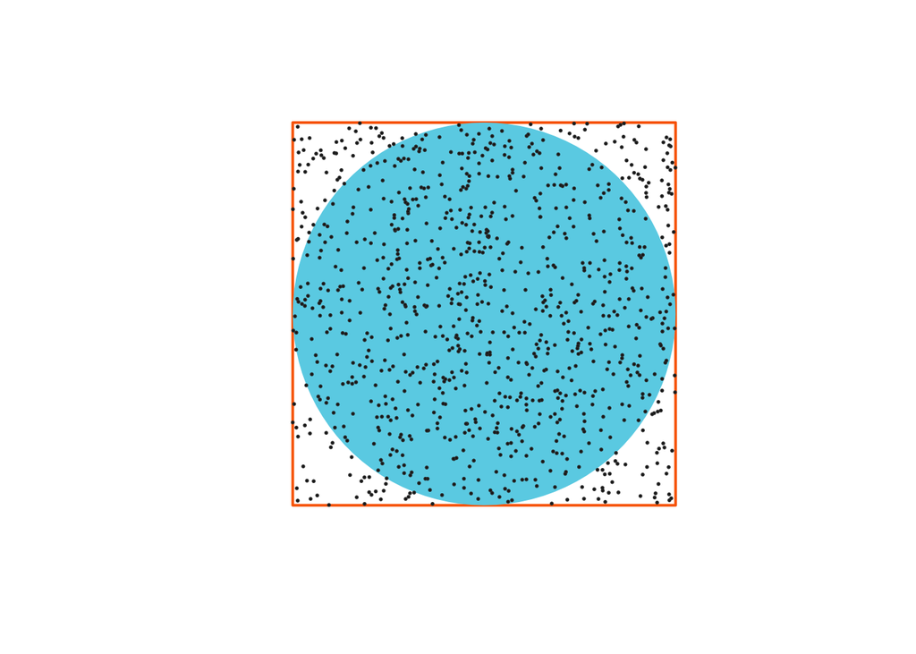

```r
n_pts <- 1000
pts <- spsample(square, n_pts, type = 'random')
plot(square, axes = F, border = '#FA6900', lwd = 2)
plot(circle, add = T, col = '#69D2E7', border = 'transparent')
plot(pts, add = T, pch = 21, cex = 0.25, col = '#333333')
```

There are a few ways determine which of these points are within the circle. First, the function `over(x, y)` in the `sp` package gives the indexes of spatial object `y` at the spatial locations of object `x`. If a given feature in `x` is not contained within `y` `NA` is returned.

```r
over(pts, circle) %>%
  sum(na.rm = T)
```

```
## [1] 798
```

Alternatively, the `sp` package offers an idiom of sorts to extract the features in one geometry that are within another geometry.

```r
(pts_within <- pts[circle, ])
```

```
## class       : SpatialPoints
## features    : 798
## extent      : -0.9881206, 0.995219, -0.9813818, 0.9869131  (xmin, xmax, ymin, ymax)
## coord. ref. : NA
```

```r
length(pts_within)
```

```
## [1] 798
```

In addition to these methods in the `sp` package, the `rgeos` package provides a more complete set of topological operations. `gIntersects()` tests if two geometries overlap, either overall (with `byid = F`) or on at the level of individual features (with `byid = T`).

```r
n_within <- gIntersects(pts, circle, byid = T) %>%
  sum
n_within
```

```
## [1] 798
```

Finally, taking the ratio of points within the circle to total points and multiplying by 4, gives an estimate of \( \pi \).

```r
(pi_est <- 4 * n_within / n_pts)
```

```
## [1] 3.192
```

```r
round(abs(100 * (pi_est / pi - 1)), 2)
```

```
## [1] 1.6
```